# Time Series Analysis

Using Prophet in R

Shruti Dharmendra Patel

16 March 2024

## 1. Using the co2 dataset

### 1.1 CO2?

The co2 dataset is a time series of the atmospheric concentrations of CO2, measured in parts per million (ppm), in Mauna Loa. The data has been recorded monthly from 1959 to 1997. The purpose of this project is to use past data to make predictions on the future atmospheric concentrations of carbon dioxide. This would also allow us to look at the trend of the CO2 concentrations to see whether the levels of CO2 have been increasing at an alarming rate.

### 1.2 Create a data frame

To create a dataframe from the co2 dataset we use data.frame() and to extract the dates from the dataset and create a time series from it we use time(). We then convert this to a a vector of dates using the function yearmon() from the zoo library.

We label the column with dates ds and the column with the co2 concentrations is labelled y.

```r
co2.df = data.frame(ds=zoo::as.yearmon(time(co2)), y=co2)
```

### 1.3 Prophet function

Use the prophet function from the prophet library to fit the model.

```r
model1 = prophet::prophet(co2.df)
```

```
## Disabling weekly seasonality. Run prophet with weekly.seasonality=TRUE to override this.
```

```
## Disabling daily seasonality. Run prophet with daily.seasonality=TRUE to override this.
```

### 1.4 Future dataframe

The function make_future_dataframe is used to create a dataframe to forecast 8 quarters

```r
forecast = prophet::make_future_dataframe(model1, periods=8, freq="quarter")
```

### 1.5 Predict

The predict function is used to get the forecast

```r
prediction = predict(model1, forecast)
tail(prediction) #gives the last 6 predicted values
```

```
##             ds    trend additive_terms additive_terms_lower
## 471 1998-09-01 365.3458     -3.0869040           -3.0869040
## 472 1998-12-01 365.6985     -0.9752536           -0.9752536
## 473 1999-03-01 366.0474      1.2326304            1.2326304
## 474 1999-06-01 366.4040      2.3515079            2.3515079
## 475 1999-09-01 366.7606     -3.0559696           -3.0559696
## 476 1999-12-01 367.1133     -0.9773037           -0.9773037
##     additive_terms_upper     yearly yearly_lower yearly_upper
## 471           -3.0869040 -3.0869040   -3.0869040   -3.0869040
## 472           -0.9752536 -0.9752536   -0.9752536   -0.9752536
## 473            1.2326304  1.2326304    1.2326304    1.2326304
## 474            2.3515079  2.3515079    2.3515079    2.3515079
## 475           -3.0559696 -3.0559696   -3.0559696   -3.0559696
## 476           -0.9773037 -0.9773037   -0.9773037   -0.9773037
##     multiplicative_terms multiplicative_terms_lower multiplicative_terms_upper
## 471                    0                          0                          0
## 472                    0                          0                          0
## 473                    0                          0                          0
## 474                    0                          0                          0
## 475                    0                          0                          0
## 476                    0                          0                          0
##     yhat_lower yhat_upper trend_lower trend_upper     yhat
## 471   361.7538   362.7568    365.2468    365.4347 362.2589
## 472   364.1565   365.2600    365.4891    365.8870 364.7233
## 473   366.6768   367.9216    365.6997    366.3703 367.2800
## 474   368.0371   369.4606    365.9169    366.8836 368.7555
## 475   362.9381   364.4810    366.1296    367.4212 363.7046
## 476   365.2103   367.0270    366.2465    367.9485 366.1360
```

### 1.6 Plot the model and the predicted dataframe

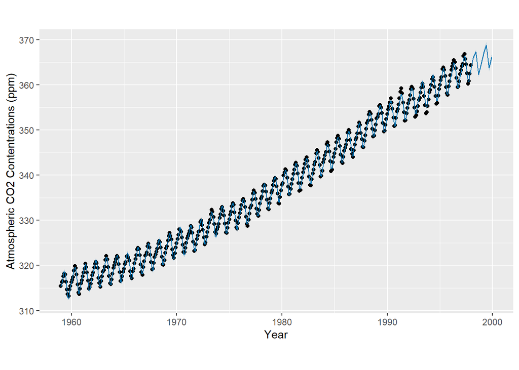

```r
plot(model1,prediction, xlabel = "Year", ylabel = "Atmospheric CO2 Contentrations (ppm)",main="Mauna Loa Atmospheric CO2 Concentration")
```

From this plot, we can see that the forecasted values (blue line) align closely with the observed values (black points). This implies that the forecasted values are likely to be accurate.

### 1.7 *Trendyy*

Let’s take a closer look at the trend.

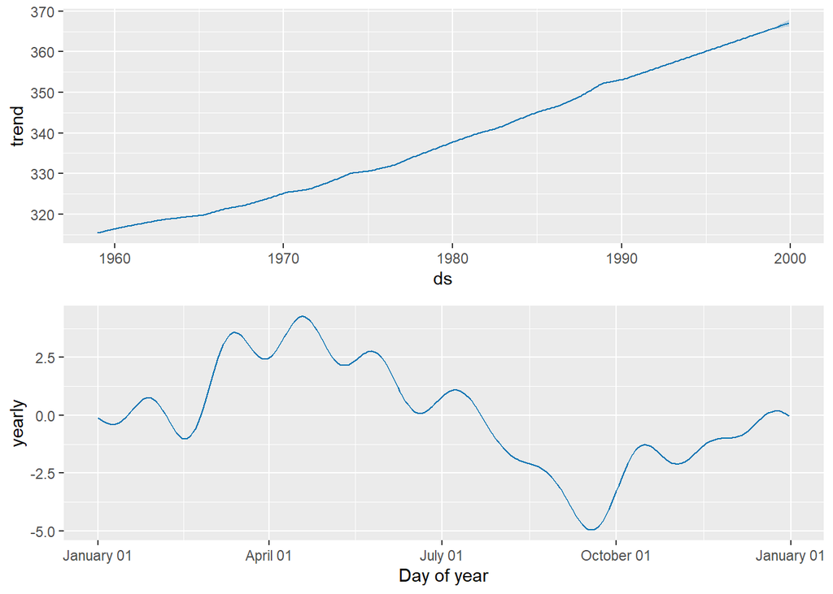

```r
prophet::prophet_plot_components(model1,prediction)
```

This shows us the trend and yearly seasonality. The trend shows that the atmospheric CO2 concentrations have an increasing trend. As for seasonality, the atmospheric concentrations of CO2 are higher between March and June.

### 1.6 To be *linear* or *not* to be *linear*

The increasing trend does not specifically mean that the trend is linear. We can fit the linear, quadratic and cubic polynomials to model the trend of the atmospheric concentration of CO2 and to check whether it is linear. But in this case, we shall simply plot a Residuals versus Fitted graph.

```r
Model2<- lm(y ~ time(ds), data = co2.df)
summary(Model2)
```

```
##
## Call:
## lm(formula = y ~ time(ds), data = co2.df)
##
## Residuals:
##     Min      1Q  Median      3Q     Max
## -6.0399 -1.9476 -0.0017  1.9113  6.5149
##
## Coefficients:
##              Estimate Std. Error t value Pr(>|t|)
## (Intercept) 3.115e+02  2.424e-01  1284.9   <2e-16 ***
## time(ds)    1.090e-01  8.958e-04   121.6   <2e-16 ***
## ---
## Signif. codes:  0 '***' 0.001 '**' 0.01 '*' 0.05 '.' 0.1 ' ' 1
##
## Residual standard error: 2.618 on 466 degrees of freedom
## Multiple R-squared:  0.9695, Adjusted R-squared:  0.9694
## F-statistic: 1.479e+04 on 1 and 466 DF,  p-value: < 2.2e-16
```

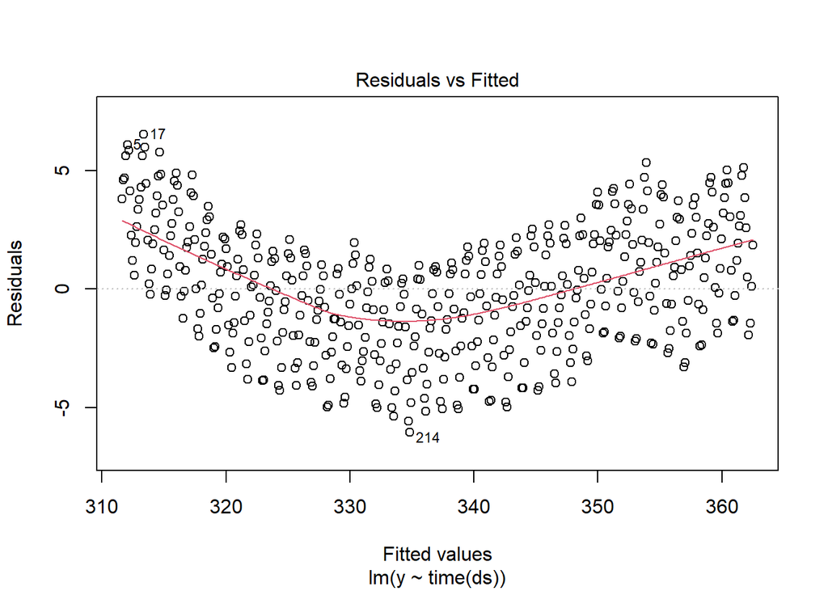

```r
plot(Model2, which = 1) #which=1 to plot the Residuals vs Fitted
```

The residuals follow a slight U-shaped pattern, therefore, the assumption of linearity is not met. From this plot, we can see that there exists homoscedasticity implying that the variance of the residuals is constant. We could test for the homoscedasticity using the Breusch–Pagan test although it is normally used to test for heteroscedasticity.

Let the null hypothesis be that the variance of the errors is constant.

```r
library(lmtest)
bptest(Model2)
```

```
##
##  studentized Breusch-Pagan test
##
## data:  Model2
## BP = 3.6238, df = 1, p-value = 0.05696
```

The test statistic is 3.6238 and the p-value is 0.05696. Since the p-value is greater than 0.05, we fail to reject the null hypothesis. Therefore there may exist homoscedasticity.

Now let’s look at another dataset…

## 2. Unemployment

*I knoww its tough these days but…oh well life moves on :)*

### 2.1 What about it??

It’s getting harder to find jobs now, so I wanted to perform time series analysis to see just how bad it is. Since the combined landmass of North and South America is larger than any other continent, we shall look at the levels of unemployment there. More specifically, in the U.S.A (which I know is just part of North America but just go with it).

I got the dataset from https://fred.stlouisfed.org/series/UNEMPLOY. The data features 2 variables: the date and the levels of unemployment in the U.S.A.The dates range from January 1960 to January 2022. The data is recorded monthly on the 1st of each month. The number of people unemployed is measured in thousands of persons.

### 2.2 Idem

Following similar steps as before I will forecast the data with a few changes to the formulas.

1. Create a data frame

The dataset is already in the format of YYYY-MM-DD so I didn’t use zoo::as.yearmon(time…) to extract the dates and covert it to a vector. I relabelled the columns from observation_date and UNEMPLOY to ds and y respectively.

```r
unemploy.df <- data.frame(ds = UNEMPLOY$observation_date, y=UNEMPLOY$UNEMPLOY)
```

```r
library(dygraphs)
dygraph(unemploy.df, main = "Unemployment levels in the U.S.A", xlab="Year", ylab="Unemployment levels (thousands of persons)") %>%
  dyRangeSelector(dateWindow = c("1960-01-01", "2022-01-01"))
```

[interactive chart not shown]

This dygraph shows the Unemployment levels in the U.S.A. It can be adjusted to zoom into a particular range of years or months.

2. Prophet function

This time I added in the daily and weekly seasonalities.

```r
model3= prophet::prophet(unemploy.df,weekly.seasonality = TRUE, daily.seasonality = TRUE)
```

3. Future dataframe

This will create a datafame to forecast monthly for 2 years

```r
forecast3= prophet::make_future_dataframe(model3, periods=24, freq="month")
```

4. Predict

```r
prediction3 = predict(model3, forecast3)
tail(prediction3) #gives the last 6 predicted values
```

```
##             ds    trend additive_terms additive_terms_lower
## 764 2023-08-01 7846.459      85.253669            85.253669
## 765 2023-09-01 7828.372     -32.173557           -32.173557
## 766 2023-10-01 7810.869    -208.775054          -208.775054
## 767 2023-11-01 7792.782       2.609929             2.609929
## 768 2023-12-01 7775.279    -177.683169          -177.683169
## 769 2024-01-01 7757.192    -107.510806          -107.510806
##     additive_terms_upper     daily daily_lower daily_upper     weekly
## 764            85.253669 -83.52827   -83.52827   -83.52827  89.923661
## 765           -32.173557 -83.52827   -83.52827   -83.52827  -5.219495
## 766          -208.775054 -83.52827   -83.52827   -83.52827 -99.027669
## 767             2.609929 -83.52827   -83.52827   -83.52827 114.437241
## 768          -177.683169 -83.52827   -83.52827   -83.52827  -5.219495
## 769          -107.510806 -83.52827   -83.52827   -83.52827  75.667474
##     weekly_lower weekly_upper    yearly yearly_lower yearly_upper
```

[output cut: 20 more lines]

5. Plot the model and the predicted dataframe

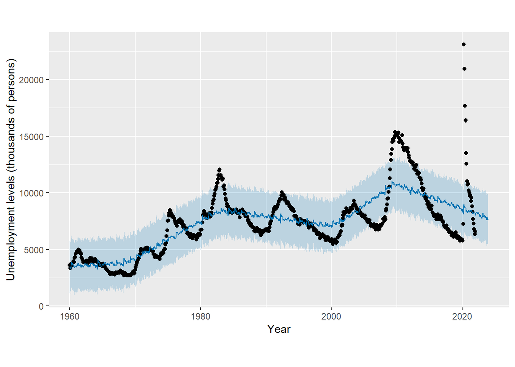

```r
plot(model3,prediction3, xlabel = "Year", ylabel = "Unemployment levels (thousands of persons)", main="Unemployment levels in the U.S.A")
```

From the graph we can see peaks at certain times and this could be due to reasons such as recession. For example, the country battled recession in 1980 and increased military spending in 1983 may have potentially led to increased unemployment in non-military areas. The high unemployment levels between 2009 and 2011 are the aftermath of the global financial crisis. The only anomaly would be the soaring unemployment levels between 2020 and 2021 that were a consequence of the Covid-19 pandemic. Looking at the observed data, there is a general pattern of increasing unemployment levels, after which they start to fall then rise again (cyclical unemployment) The predicted values don’t closely follow the observed values but they do follow the general pattern of rising and falling unemployment levels as the observed data.

6. Trend

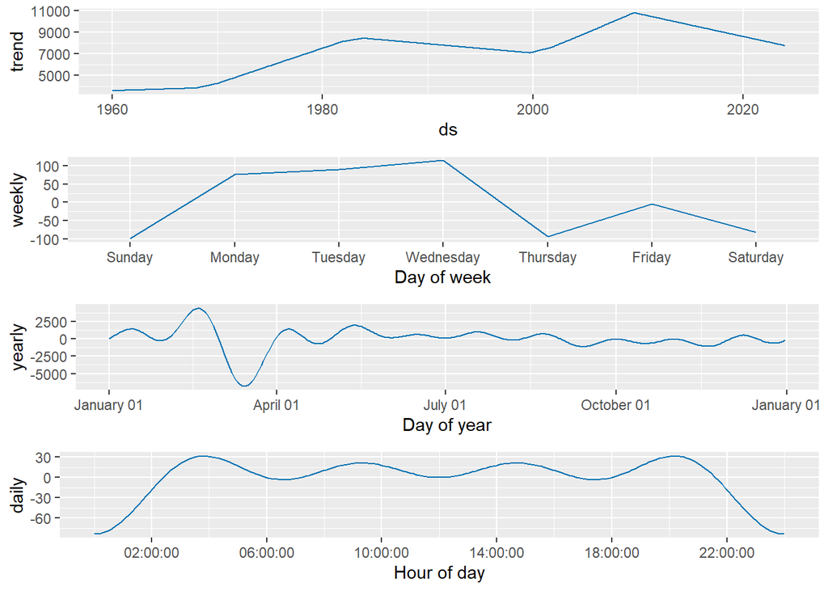

```r
prophet::prophet_plot_components(model3,prediction3)
```

7. To be *linear* or *not* to be *linear*

Let’s try the Linear Trend for this.

```r
Model4 <- lm(y~ds, data=unemploy.df)
summary(Model4)
```

```
##
## Call:
## lm(formula = y ~ ds, data = unemploy.df)
##
## Residuals:
##    Min     1Q Median     3Q    Max
##  -4528  -1547   -388   1376  12816
##
## Coefficients:
##              Estimate Std. Error t value Pr(>|t|)
## (Intercept) 5.196e+03  1.255e+02   41.39   <2e-16 ***
## ds          3.202e-06  1.441e-07   22.22   <2e-16 ***
## ---
## Signif. codes:  0 '***' 0.001 '**' 0.01 '*' 0.05 '.' 0.1 ' ' 1
##
## Residual standard error: 2224 on 743 degrees of freedom
## Multiple R-squared:  0.3993, Adjusted R-squared:  0.3985
## F-statistic: 493.9 on 1 and 743 DF,  p-value: < 2.2e-16
```

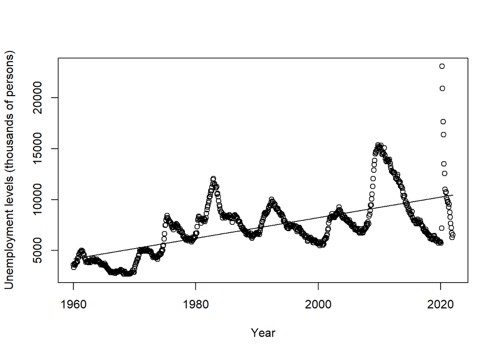

```r
plot(unemploy.df$ds, unemploy.df$y, type="p", xlab="Year", ylab="Unemployment levels (thousands of persons)")
points(unemploy.df$ds, fitted(Model4), type="l")
```

Can’t say that the linearity assumption has been met without more tests but the linear model does follow an increasing trend like the observed data.

*Another one bites the dust!*